# NH importance sampler

## Introduction

This document contains two main parts

- uniform and NH approximations
- A series of solver problems increasing in complexity to find the proper formulation of the NH sampler

## 28.08.2019

We consider a simple tree with only one branche, and $T=1$, and we perform samples with both Uniform and Non-homogenous (NH) data augmentation algorithms. For that we use the `mc_sample_independent_trees` function on the `emphasis` package.

```r
brts=c(1)
pars = c(2,-0.1,1)
nsim_unif = 1000000
nsim_emph=1000000
st_unif = mc_sample_independent_trees(brts = brts,pars = pars,nsim = nsim_unif,model = "dd",method = "uniform",no_cores = 2,maxnumspec = 10)
st_nh = mc_sample_independent_trees(brts = brts,pars = pars,nsim = nsim_emph,model = "dd",method = "emphasis",no_cores = 2)
```

The object `st_*` is a list with all information regarding the simulated set of trees.

We now analize the set of tree by partioning it by dimension (number of missing species). So, the simplest space is the space with zero missing species, which consists on only one tree. We check if the theoritical sampling probability is coherent with the empirical sampling probability. With uniform IS:

```r
#### d = 0
indexes_unif = which((st_unif$dim-1)/2==0)
length(indexes_unif)/nsim_unif
```

```
## [1] 0.09069
```

```r
mean(exp(st_unif$logg[indexes_unif]))
```

```
## [1] 0.09090909
```

With NH IS: #

```r
indexes_nh = which((st_nh$dim-1)/2==0)
length(indexes_nh)/nsim_emph
```

```
## [1] 0.496568
```

```r
mean(exp(st_nh$logg[indexes_nh]))
```

```
## [1] 0.4970966
```

Now we check if the contribution to the likelihood is stochastically equivalent with different ISs

```r
sum(st_unif$weights[indexes_unif])/nsim_unif
```

```
## [1] 0.05489061
```

```r
sum(st_nh$weights[indexes_nh])/nsim_emph
```

```
## [1] 0.05496471
```

[x] Unifrom sampling [x] nh sampling [x] both are in agreement

### Now we analyze space of trees with one missing species

We have that

$$g(D) = \int g(x)dx = \frac{1}{p}\sum g(x_i)$$

```r
#### d=1
indexes_unif_d1 = which((st_unif$dim-1)/2==1)
length(indexes_unif_d1)/nsim_unif
```

```
## [1] 0.091305
```

```r
mean(exp(st_unif$logg[indexes_unif_d1]))
```

```
## [1] 0.09090909
```

```r
indexes_emph_d1 = which((st_nh$dim-1)/2==1)
length(indexes_emph_d1)/nsim_emph
```

```
## [1] 0.234679
```

```r
mean(exp(st_nh$logg[indexes_emph_d1]))
```

```
## [1] 0.6444039
```

```r
sum(st_unif$weights[indexes_unif_d1])/nsim_unif
```

```
## [1] 0.05086868
```

```r
sum(st_nh$weights[indexes_emph_d1])/nsim_emph
```

```
## [1] 0.01976163
```

```r
st=st_unif
st2=st_nh
#ggplot(data.frame(g=exp(st2$logg[indexes_e])))+geom_histogram(aes(x=g))+geom_vline(xintercept = length(indexes_e)/nsim_emph)+geom_vline(xintercept = mean(exp(st2$logg[indexes_e])))
```

moreover, we calculate the likelihood analitically

```r
lambda0 = 2
mu = 1
beta = -0.1
lambda_t <- function(N){lambda0 + beta*N}
b = 1

log_f_one_missing <- function(text,tspe){
  -lambda_t(1) * (tspe-(exp(-b*mu)/mu) *  (exp(tspe*mu)-1)) + log(lambda_t(1)) + log(mu) -mu*text  -2*lambda_t(2) * (text-tspe-(exp(-b*mu)/mu) *  (exp(text*mu)-exp(tspe*mu))) - lambda_t(1) * (b-text-(exp(-b*mu)/mu) * (exp(b*mu)-exp(text*mu)))
}

log_f_one_missing_tspe <- function(tspe){
  int=NULL
  for(i in 1:length(tspe)){
    int[i] = integrate(log_f_one_missing,lower=tspe[i],upper=b,tspe=tspe[i])$value
  }
  return(int)
}

f_one_missing <- function(text,tspe){
  0.95*exp(1.8*(tspe-text)-1.7*(exp(tspe-1)-exp(text-1))+1.9*(-exp(-1)))
}

int_f_one_missing_spe <- function(tspe){
  int=NULL
  for(i in 1:length(tspe)){
    int[i] = integrate(f_one_missing,lower=tspe[i],upper=1,tspe=tspe[i])$value
  }
  return(int)
}

Int=integrate(log_f_one_missing_tspe,lower=0,upper=b)
exp(Int$value)
```

```
## [1] 0.6256025
```

```r
Int2=integrate(int_f_one_missing_spe,lower=0,upper=1)
Int2$value
```

```
## [1] 0.1873483
```

```r
st_unif$Etime
```

```
## [1] 964.505
```

```r
st_nh$Etime
```

```
## [1] 1444.291
```

### does NHPP simulation do the job?

$$g(x|y) = \lambda \left( 1-e^{-\mu ( T - t)}\right)e^{-\lambda\int_0^{t^{Sp}} \left( 1-e^{-\mu ( T - t)}\right)dt}$$

```r
log_F_NHPPSpe <- function(t,s,mu,r){
  -s*(t-(exp(-mu*r)/mu)*(exp(mu*t)-1))
}

s = 1.9
mu = 1
b = r = 1

nsim = 1000000
rnh=NULL
for(i in 1:nsim){
  rnh[i] = rnhpp(s=s,mu=mu,r=b)
}

exp(log_F_NHPPSpe(0.25,s,mu,r))
```

```
## [1] 0.758453
```

```r
sum(rnh>0.25)/nsim
```

```
## [1] 0.758928
```

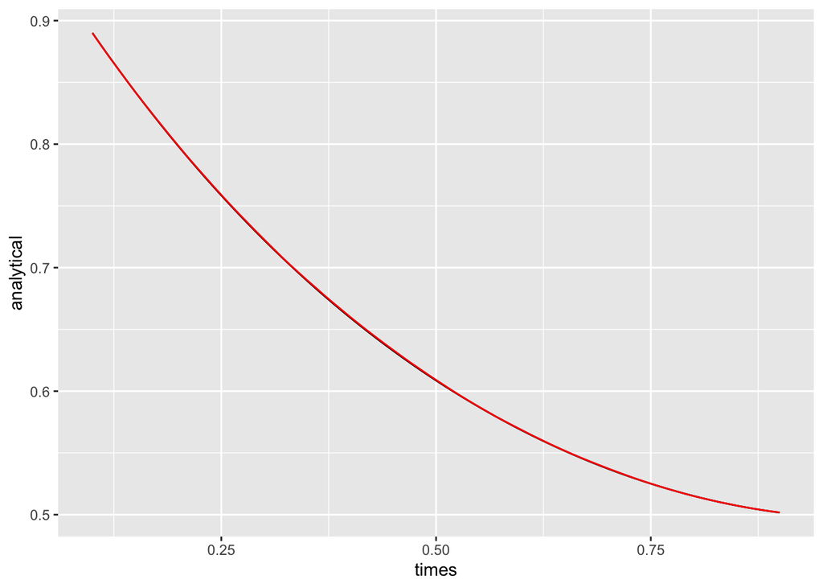

```r
times_b <- seq(0.1,0.9,by=0.01)

analytical=empirical=NULL
for(i in 1:length(times_b)){
  analytical[i] = exp(log_F_NHPPSpe(times_b[i],s,mu,r))
  empirical[i] = sum(rnh>times_b[i])/nsim
}
## seems to work fine
ggplot(data.frame(times=times_b,analytical=analytical,empirical=empirical))+geom_line(aes(x=times,y=analytical))+geom_line(aes(x=times,y=empirical),colour="red")
```

## We check that the memoryless property works on the non-homogenous case too

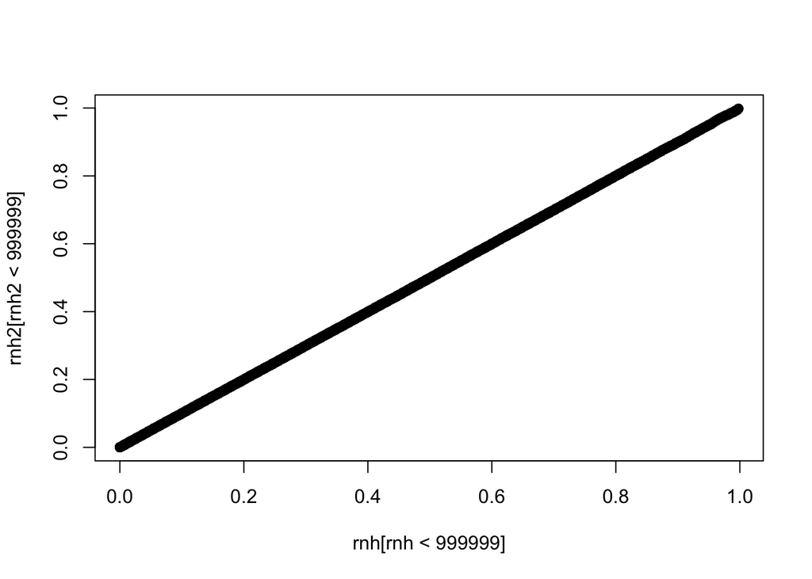

```r
b1=0.5

nsim = 1000000
rnh2=NULL
for(i in 1:nsim){
  rnh_temp = rnhpp(s=s,mu=mu,r=b)
  if(rnh_temp<b1){
    rnh2[i] = rnh_temp
  }else{
    rnh2[i] = rnhpp(s=s,mu=mu,r=b-b1)+b1
  }

}

qqplot(rnh[rnh<999999],rnh2[rnh2<999999])
```

```r
summary(rnh)
```

```
##      Min.   1st Qu.    Median      Mean   3rd Qu.      Max.
## 0.0000008 0.2618476 0.9212811       Inf       Inf       Inf
```

```r
summary(rnh2)
```

```
##      Min.   1st Qu.    Median      Mean   3rd Qu.      Max.
## 0.0000006 0.2614870 0.9196447       Inf       Inf       Inf
```

## what if rate changes step-wise?

$$f(x) = \prod_i e^{-i \lambda}$$

```r
b1=0.5

nsim = 100000
rnh2=NULL
for(i in 1:nsim){
  rnh_temp = rnhpp(s=s,mu=mu,r=b)
  if(rnh_temp<b1){
    rnh2[i] = rnh_temp
  }else{
    rnh2[i] = rnhpp(s=2*s,mu=mu,r=b-b1)+b1
  }

}

qqplot(rnh[rnh<999999],rnh2[rnh2<999999])
summary(rnh)
summary(rnh2)
```

## now we include extinction

$$g(x|y) = \lambda \mu e^{-\lambda\int_0^{t^{Sp}} \left( 1-e^{-\mu ( T - t)}\right)dt} e^{-\mu t^{Ex}_{j}}$$

```r
s = 1.9
mu = 1
b = r = 2

nsim = 1000000
rnh=et=NULL
for(i in 1:nsim){
  rnh[i] = rnhpp(s=s,mu=mu,r=b)
  if(rnh[i]<b){
    et[i] = rnh[i] + truncdist::rtrunc(1,"exp",a = 0, b = (b-rnh[i]),rate=mu)
  }else{
    et[i] = Inf
  }
}

f_NHPPSpeExt <- function(tspe,text){
  mu*s*exp(-mu*(text-tspe))*exp(-s*(tspe-(exp(-mu*r)/mu)*(exp(mu*tspe)-1)))
}
Int = integral2(f_NHPPSpeExt,0.1,0.2,0.7,0.8)
sum(rnh>0.1 & rnh<0.2 & et>0.7 & et<0.8)/nsim
```

```
## [1] 0.008102
```

```r
Int$Q
```

```
## [1] 0.008180426
```

## Now, we allow multples processes with a step-wise changing rate

$$g(x|y) = \left[\prod^{p}_{i=1}e^{-\int^{t_{i}}_{t_{i-1}} N_t\lambda_{t} \left( 1-e^{-\mu ( T_{i} -t)}\right) dt} \right] \left[ \prod^{M_{e}}_{j=1} N_{t^{Sp}_j}\lambda_{t^{Sp}_j} \mu e^{-\mu t^{Ex}_{j}} \right]$$

```r
lambda0 = 2
mu = 2
beta = -0.1
lambda_t <- function(N){lambda0 + beta*N}
b = 1

nsim = 1000000
rnh=et=NULL
ct = 0

while(ct<b){
  rnh[i] = rnhpp(s=s,mu=mu,r=b)
  ct = ct + rnh[i]
  if(ct < b){
    et[i] = ct + truncdist::rtrunc(1,"exp",a = 0, b = (b-ct),rate=mu)
  }
}
for(i in 1:nsim){
  rnh[i] = rnhpp(s=s,mu=mu,r=b)
  if(rnh[i]<b){
    et[i] = rnh[i] + truncdist::rtrunc(1,"exp",a = 0, b = (b-rnh[i]),rate=mu)
  }else{
    et[i] = Inf
  }
}
```

## finally, we observe at the whole tree

$$g(x|y) = \left[\prod^{p}_{i=1}e^{-\int^{t_{i}}_{t_{i-1}} N_t\lambda_{t} \left( 1-e^{-\mu ( T_{i} -t)}\right) dt} \right] \left[ \prod^{M_{e}}_{j=1} \frac{N_{t^{Sp}_j}}{(2N^{o}_{t_j^-}+N^{e}_{t_j^-})}\lambda_{t^{Sp}_j} \mu e^{-\mu t^{Ex}_{j}} \right]$$

On the DD case $\lambda_t = \lambda_0 + \beta1 N_t$ is constant in the interval $[t_{i-1},t_i]$ for all $i$. We then have

$$g(x|y) = \left[\prod^{p}_{i=1}e^{- N_{t_{i-1}}\lambda_{t_{i-1}}\left[t_{i}-t_{i-1}-\frac{e^{-\mu T}}{\mu}(e^{\mu t_i}-e^{\mu t_{i-1}})\right]} \right] \left[ \prod^{M_{e}}_{j=1} \frac{N_{t^{Sp}_j}}{(2N^{o}_{t_j^-}+N^{e}_{t_j^-})}\lambda_{t^{Sp}_j} \mu e^{-\mu t^{Ex}_{j}} \right]$$

or in the logarithm space

$$\log(g(x|y)) = \left[\sum^{p}_{i=1}- N_{t_{i-1}}\lambda_{t_{i-1}}\left[t_{i}-t_{i-1}-\frac{e^{-\mu T}}{\mu}(e^{\mu t_i}-e^{\mu t_{i-1}})\right] \right] \left[ \sum^{M_{e}}_{j=1} \log{N_{t^{Sp}_j}}-log{(2N^{o}_{t_j^-}+N^{e}_{t_j^-})} +log{\lambda_{t^{Sp}_j}} +\log{\mu} {-\mu t^{Ex}_{j}} \right]$$

```r
save(st2,file="5Sept.RData")
b=1
df = st2$trees[[8]]
# at everyone branching point
to = top = head(df$to,-1)
to[to==2] = 1
initspec=1
n = c(initspec,initspec+cumsum(to)+cumsum(to-1))
lambda = lambda.dd(pars,n)
brts_i = df$brts
brts_im1 = c(0,df$brts[-nrow(df)])
# at missing speciation times
missing_speciations = (df$to == 1)
nb = n[missing_speciations]
No = c(1,1+cumsum(top==2))[missing_speciations]
Ne = c(0,cumsum(top==1)-cumsum(top==0))[missing_speciations]
lambda_b = lambda[missing_speciations]
text = df$t.ext[missing_speciations]
mu = pars[3]
logg = sum(-n * lambda * (brts_i-brts_im1-(exp(-b*mu)/mu) *  (exp(brts_i*mu)-exp(brts_im1*mu))  ))+sum(log(nb)+log(mu)-sum(mu*text)+sum(log(lambda_b))-log(2*No+Ne))

logg
```

```
## [1] -0.8233895
```

```r
st2$logg[8]
```

```
## [1] -0.1302423
```

```r
print(paste(c("primera",sum(-n * lambda * (brts_i-brts_im1-(exp(-b*mu)/mu) *  (exp(brts_i*mu)-exp(brts_im1*mu))  )))))
```

```
## [1] "primera"            "-0.707324184732999"
```

```r
print(paste(c("segunda",sum(log(nb)+log(mu)-sum(mu*text)+sum(log(lambda_b))-log(2*No+Ne)))))
```

```
## [1] "segunda"            "-0.116065344293901"
```

```r
print(paste(c("extra",b)))
```

```
## [1] "extra" "1"
```

```r
tree = emphasis::df2tree(df=df,pars,model="dd",initspec=initspec)
wt=tree$wt
to=tree$to
n=tree$n
s=tree$s
r=tree$r
t_ext=tree$t_ext
top_aug=head(tree$treeaug,-1)
mu = pars[3]
sa = s[is.finite(t_ext)]
text = t_ext[is.finite(t_ext)]
logg = sum(-s * (wt-(exp(-r*mu)/mu) *  (exp(wt*mu)-1)  ))+sum(is.finite(t_ext))*log(mu)-sum(mu*text)+sum(log(sa))+log.factor.samp.prob_emph(top_aug)
logg
```

```
## [1] -0.8233895
```

```r
st2$logg[8]
```

```
## [1] -0.1302423
```

```r
log_sampling_prob_emphasis(tree = df,pars = pars,model = "dd",initspec = 1)
```

```
## [1] -0.8233895
```

```r
print(paste(c("primera",sum(-s * (wt-(exp(-r*mu)/mu) *  (exp(wt*mu)-1)  )))))
```

```
## [1] "primera"            "-0.707324184732999"
```

```r
print(paste(c("segunda",sum(is.finite(t_ext))*log(mu)-sum(mu*text)+sum(log(sa))+log.factor.samp.prob_emph(top_aug))))
```

```
## [1] "segunda"            "-0.116065344293901"
```

its the first term. so we focuss on it

```r
to = top = head(df$to,-1)
to[to==2] = 1
initspec=1
n = c(initspec,initspec+cumsum(to)+cumsum(to-1))
lambda = lambda.dd(pars,n)
brts_i = df$brts
brts_im1 = c(0,df$brts[-nrow(df)])
# at missing speciation times
missing_speciations = (df$to == 1)
nb = n[missing_speciations]
No = c(1,1+cumsum(top==2))[missing_speciations]
Ne = c(0,cumsum(top==1)-cumsum(top==0))[missing_speciations]
lambda_b = lambda[missing_speciations]
text = df$t.ext[missing_speciations]

logg = sum(-n * lambda * (brts_i-brts_im1-(exp(-b*mu)/mu) *  (exp(brts_i*mu)-exp(brts_im1*mu))  ))+sum(log(nb)+log(mu)-sum(mu*text)+sum(log(lambda_b))-log(2*No+Ne))


print(paste(c("primera: ",-sum(n * lambda))))
```

```
## [1] "primera: " "-7.4"
```

```r
print(paste(c("segunda: ",sum((brts_i-brts_im1-(exp(-b*mu)/mu) *  (exp(brts_i*mu)-exp(brts_im1*mu)))))))
```

```
## [1] "segunda: "         "0.367879441171442"
```

```r
tree = emphasis::df2tree(df=df,pars,model="dd",initspec=initspec)
wt=tree$wt
to=tree$to
n=tree$n
s=tree$s
r=tree$r
t_ext=tree$t_ext
top_aug=head(tree$treeaug,-1)
mu = pars[3]
sa = s[is.finite(t_ext)]
text = t_ext[is.finite(t_ext)]
logg = sum(-s * (wt-(exp(-r*mu)/mu) *  (exp(wt*mu)-1)  ))+sum(is.finite(t_ext))*log(mu)-sum(mu*text)+sum(log(sa))+log.factor.samp.prob_emph(top_aug)
print(paste(c("primera: ",-sum(s))))
```

```
## [1] "primera: " "-7.4"
```

```r
print(paste(c("segunda: ",sum((wt-(exp(-r*mu)/mu) *  (exp(wt*mu)-1))))))
```

```
## [1] "segunda: "         "0.367879441171442"
```

its the second. so we go further

```r
b=1
to = top = head(df$to,-1)
to[to==2] = 1
initspec=1
n = c(initspec,initspec+cumsum(to)+cumsum(to-1))
lambda = lambda.dd(pars,n)
brts_i = df$brts
brts_im1 = c(0,df$brts[-nrow(df)])
# at missing speciation times
missing_speciations = (df$to == 1)
nb = n[missing_speciations]
No = c(1,1+cumsum(top==2))[missing_speciations]
Ne = c(0,cumsum(top==1)-cumsum(top==0))[missing_speciations]
lambda_b = lambda[missing_speciations]
text = df$t.ext[missing_speciations]

logg = sum(-n * lambda * (brts_i-brts_im1-(exp(-b*mu)/mu) *  (exp(brts_i*mu)-exp(brts_im1*mu))  ))+sum(log(nb)+log(mu)-sum(mu*text)+sum(log(lambda_b))-log(2*No+Ne))

print(paste(c("primera: ",brts_i-brts_im1)))
```

```
## [1] "primera: "          "0.8885463539242"    "0.0647720499063502"
## [4] "0.0466815961694502"
```

```r
print(paste(c("segunda: ",-(exp(-b*mu)/mu) *  (exp(brts_i*mu)-exp(brts_im1*mu)))))
```

```
## [1] "segunda: "           "-0.526653414378985"  "-0.0598583754903158"
## [4] "-0.0456087689592565"
```

```r
print(paste(c("extra info: ",brts_i,b)))
```

```
## [1] "extra info: "     "0.8885463539242"  "0.95331840383055"
## [4] "1"                "1"
```

```r
tree = emphasis::df2tree(df=df,pars,model="dd",initspec=initspec)
wt=tree$wt
to=tree$to
n=tree$n
s=tree$s
r=tree$r
t_ext=tree$t_ext
top_aug=head(tree$treeaug,-1)
mu = pars[3]
sa = s[is.finite(t_ext)]
text = t_ext[is.finite(t_ext)]
logg = sum(-s * (wt-(exp(-r*mu)/mu) *  (exp(wt*mu)-1)  ))+sum(is.finite(t_ext))*log(mu)-sum(mu*text)+sum(log(sa))+log.factor.samp.prob_emph(top_aug)
print(paste(c("primera: ",wt)))
```

```
## [1] "primera: "          "0.8885463539242"    "0.0647720499063502"
## [4] "0.0466815961694502"
```

```r
print(paste(c("segunda: ",-(exp(-r*mu)/mu) *  (exp(wt*mu)-1))))
```

```
## [1] "segunda: "           "-0.526653414378985"  "-0.0598583754903159"
## [4] "-0.0456087689592565"
```

```r
print(paste(c("extra info: ",r)))
```

```
## [1] "extra info: "       "1"                  "0.1114536460758"
## [4] "0.0466815961694502"
```

with that we can calculate the sampling probability

```r
log_sampling_prob_emphasis <- function(tree,pars,model=NULL,initspec){
  tree = emphasis::df2tree(df=tree,pars,model=model,initspec=initspec)
  wt=tree$wt
  to=tree$to
  n=tree$n
  s=tree$s
  r=tree$r
  t_ext=tree$t_ext
  top_aug=head(tree$treeaug,-1)
  mu = pars[3]
  if(mu!=0){
    sa = s[is.finite(t_ext)]
    text = t_ext[is.finite(t_ext)]
    logg = sum(-s * (wt-(exp(-r*mu)/mu) *  (exp(wt*mu)-1)  ))+sum(is.finite(t_ext))*log(mu)-sum(mu*text)+sum(log(sa))+log.factor.samp.prob_emph(top_aug)
  }else{
    logg = 0
  }
  return(logg)
}

log.factor.samp.prob_emph <- function(to){
  top = head(to,-1)
  number.observed = c(1,1+cumsum(top==2))
  number.missing = c(0,cumsum(top==1)-cumsum(top==0))
  factor = -sum(log((2*number.observed+number.missing)[to==1]))
  return(factor)
}
```

going to the code, trees are data frames with information abou branching times and allocation

```r
st2$trees[[8]]
```

```
##        brts       bte to      t.ext         r
## 1 0.8885464 0.9533184  1 0.06477205 1.0000000
## 3 0.9533184       Inf  0        Inf 0.1114536
## 2 1.0000000       Inf  2        Inf 0.0466816
```

```r
emphasis::df2tree(df=st2$trees[[8]],pars,model="dd",initspec=1)
```

```
## $wt
## [1] 0.88854635 0.06477205 0.04668160
##
## $to
## [1] 1 0
##
## $n
## [1] 1 2 1
##
## $s
## [1] 1.9 3.6 1.9
##
## $r
## [1] 1.0000000 0.1114536 0.0466816
##
## $pars
## [1]  2.0 -0.1  1.0
##
## $t_ext
## [1] 0.06477205        Inf        Inf
##
## $treeaug
## [1] 1 0 2
```

```r
log_sampling_prob_nh <- function(tree,pars,model=NULL,initspec){
  tree = emphasis::df2tree(df=tree,pars,model=model,initspec=initspec)
  mu = pars[3]
  if(mu!=0){
    sa = s[is.finite(t_ext)]
    text = t_ext[is.finite(t_ext)]
    logg = sum(-s * (wt-(exp(-r*mu)/mu) * (exp(wt*mu)-1)  ))+sum(is.finite(t_ext))*log(mu)-sum(mu*text)+sum(log(sa))+log.factor.samp.prob_emph(top_aug)
  }else{
    logg = 0
  }
  return(logg)
}


log.factor.samp.prob_emph <- function(to){
  top = head(to,-1)
  number.observed = c(1,1+cumsum(top==2))
  number.missing = c(0,cumsum(top==1)-cumsum(top==0))
  factor = -sum(log((2*number.observed+number.missing)[to==1]))
  return(factor)
}
```

# Appendix

### Now in the space of two missing species

```r
#### d=2
indexes = which((st$dim-1)/2==2)
length(indexes)/nsim_unif
```

```
## [1] 0.091147
```

```r
summary(exp(st$logg[indexes]))
```

```
##    Min. 1st Qu.  Median    Mean 3rd Qu.    Max.
## 0.09091 0.09091 0.27273 0.18209 0.27273 0.27273
```

```r
indexes_e = which((st2$dim-1)/2==2)

length(indexes_e)/nsim_emph
```

```
## [1] 0.12848
```

```r
summary(exp(st2$logg[indexes_e]))
```

[output not shown]

```r
sum(st$weights[indexes])/nsim_unif
```

```
## [1] 0.02816612
```

```r
sum(st2$weights[indexes_e])/nsim_emph
```

```
## [1] 0.008545886
```

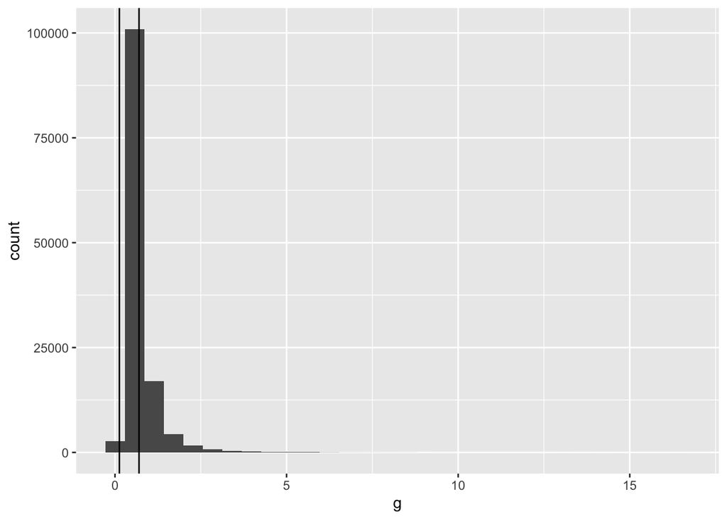

```r
ggplot(data.frame(g=exp(st2$logg[indexes_e])))+geom_histogram(aes(x=g))+geom_vline(xintercept = length(indexes_e)/nsim_emph)+geom_vline(xintercept = mean(exp(st2$logg[indexes_e])))
```

three missing species

```r
#### d=3
indexes = which((st$dim-1)/2==3)
length(indexes)/nsim_unif
```

```
## [1] 0.090945
```

```r
summary(exp(st$logg[indexes]))
```

```
##    Min. 1st Qu.  Median    Mean 3rd Qu.    Max.
##  0.1136  0.1136  0.3409  0.7631  0.6818  2.0455
```

```r
indexes_e = which((st2$dim-1)/2==3)

length(indexes_e)/nsim_emph
```

```
## [1] 0.07004
```

```r
summary(exp(st2$logg[indexes_e]))
```

```
##    Min. 1st Qu.  Median    Mean 3rd Qu.    Max.
## 0.05577 0.62821 1.00127 1.11168 1.49670 3.32774
```

```r
sum(st$weights[indexes])/nsim_unif
```

```
## [1] 0.01237241
```

```r
sum(st2$weights[indexes_e])/nsim_emph
```

```
## [1] 0.003714183
```

four missing species

```r
#### d=4
indexes = which((st$dim-1)/2==4)
length(indexes)/nsim_unif
```

```
## [1] 0.090536
```

```r
summary(exp(st$logg[indexes]))
```

```
##    Min. 1st Qu.  Median    Mean 3rd Qu.    Max.
##  0.1326  0.2652  1.5909  5.9058  9.5455 28.6364
```

```r
indexes_e = which((st2$dim-1)/2==4)

length(indexes_e)/nsim_emph
```

```
## [1] 0.037103
```

```r
summary(exp(st2$logg[indexes_e]))
```

```
##    Min. 1st Qu.  Median    Mean 3rd Qu.    Max.
## 0.04782 0.69494 1.18974 1.40972 1.91600 6.00810
```

```r
sum(st$weights[indexes])/nsim_unif
```

```
## [1] 0.004747906
```

```r
sum(st2$weights[indexes_e])/nsim_emph
```

```
## [1] 0.001570582
```

likelihood

```r
#### likelihood
sum(st$weights)/nsim_unif
```

```
## [1] 0.1535954
```

```r
sum(st2$weights)/nsim_emph
```

```
## [1] 0.08953825
```

## smaller extinction rate

```r
brts=c(1)
pars = c(2,-0.1,0.1)
nsim_unif = 1000000
nsim_emph=1000000
st = mc_sample_independent_trees(brts = brts,pars = pars,nsim = nsim_unif,model = "dd",method = "uniform",no_cores = 2,maxnumspec = 10)
st2 = mc_sample_independent_trees(brts = brts,pars = pars,nsim = nsim_emph,model = "dd",method = "emphasis",no_cores = 2)
```

We now check at the space of trees (1 tree) with zeo missing species, first if the theoritical sampling probability is coherent with the empirical sampling probability. With uniform IS:

```r
#### d = 0
indexes = which((st$dim-1)/2==0)
length(indexes)/nsim_unif
```

```
## [1] 0.090524
```

```r
summary(exp(st$logg[indexes]))
```

```
##    Min. 1st Qu.  Median    Mean 3rd Qu.    Max.
## 0.09091 0.09091 0.09091 0.09091 0.09091 0.09091
```

With NH IS: #

```r
indexes_nh = which((st2$dim-1)/2==0)
length(indexes_nh)/nsim_emph
```

```
## [1] 0.912039
```

```r
summary(exp(st2$logg[indexes_nh]))
```

```
##    Min. 1st Qu.  Median    Mean 3rd Qu.    Max.
##  0.9122  0.9122  0.9122  0.9122  0.9122  0.9122
```

Now we check if the contribution to the likelihood is stochastically equivalent with different ISs

```r
sum(st$weights[indexes])/nsim_unif
```

```
## [1] 0.134762
```

```r
sum(st2$weights[indexes_nh])/nsim_emph
```

```
## [1] 0.1353134
```

Now we analyze space of trees with one missing species

```r
#### d=1
indexes = which((st$dim-1)/2==1)
length(indexes)/nsim_unif
```

```
## [1] 0.09065
```

```r
summary(exp(st$logg[indexes]))
```

```
##    Min. 1st Qu.  Median    Mean 3rd Qu.    Max.
## 0.09091 0.09091 0.09091 0.09091 0.09091 0.09091
```

```r
indexes_e = which((st2$dim-1)/2==1)
length(indexes_e)/nsim_emph
```

```
## [1] 0.079613
```

```r
summary(exp(st2$logg[indexes_e]))
```

```
##    Min. 1st Qu.  Median    Mean 3rd Qu.    Max.
##  0.1445  0.1585  0.1647  0.1635  0.1694  0.1733
```

```r
sum(st$weights[indexes])/nsim_unif
```

```
## [1] 0.01530401
```

```r
sum(st2$weights[indexes_e])/nsim_emph
```

```
## [1] 0.007443236
```

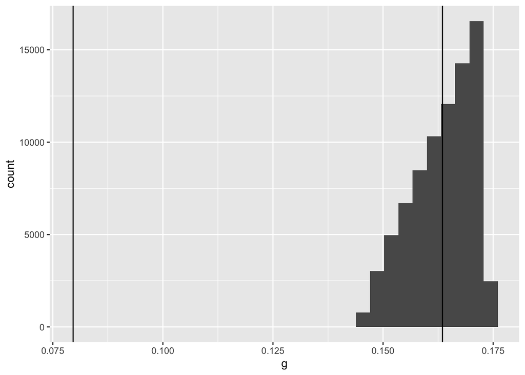

```r
ggplot(data.frame(g=exp(st2$logg[indexes_e])))+geom_histogram(aes(x=g))+geom_vline(xintercept = length(indexes_e)/nsim_emph)+geom_vline(xintercept = mean(exp(st2$logg[indexes_e])))
```

Now in the space of two missing species

```r
#### d=2
indexes = which((st$dim-1)/2==2)
length(indexes)/nsim_unif
```

```
## [1] 0.090938
```

```r
summary(exp(st$logg[indexes]))
```

```
##    Min. 1st Qu.  Median    Mean 3rd Qu.    Max.
## 0.09091 0.09091 0.27273 0.18227 0.27273 0.27273
```

```r
indexes_e = which((st2$dim-1)/2==2)

length(indexes_e)/nsim_emph
```

```
## [1] 0.00758
```

```r
summary(exp(st2$logg[indexes_e]))
```

```
##    Min. 1st Qu.  Median    Mean 3rd Qu.    Max.
## 0.02213 0.02689 0.02871 0.02866 0.03050 0.03291
```

```r
sum(st$weights[indexes])/nsim_unif
```

```
## [1] 0.001071604
```

```r
sum(st2$weights[indexes_e])/nsim_emph
```

```
## [1] 0.0004772118
```

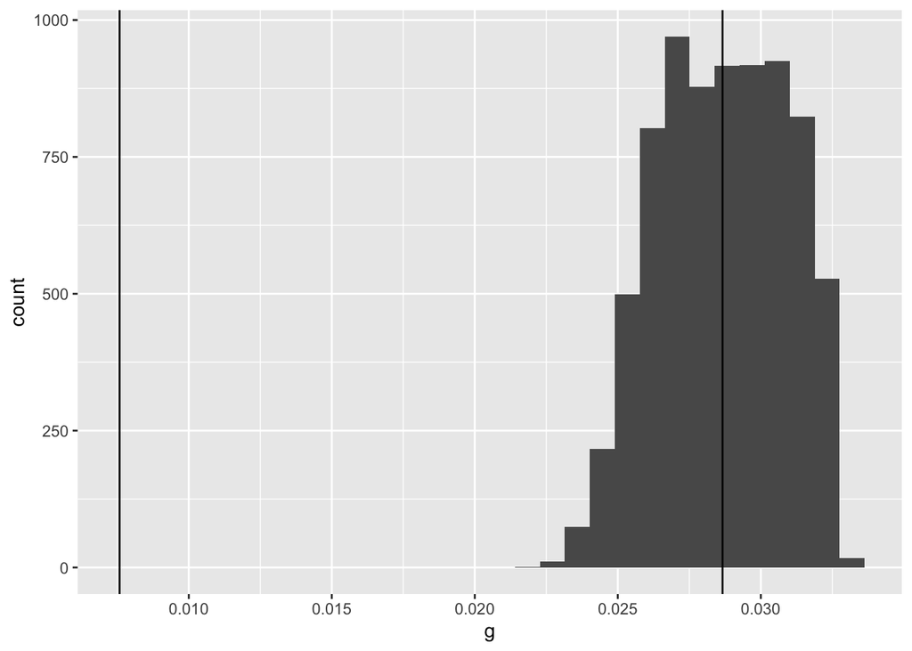

```r
ggplot(data.frame(g=exp(st2$logg[indexes_e])))+geom_histogram(aes(x=g))+geom_vline(xintercept = length(indexes_e)/nsim_emph)+geom_vline(xintercept = mean(exp(st2$logg[indexes_e])))
```

three missing species

```r
#### d=3
indexes = which((st$dim-1)/2==3)
length(indexes)/nsim_unif
```

```
## [1] 0.091289
```

```r
summary(exp(st$logg[indexes]))
```

```
##    Min. 1st Qu.  Median    Mean 3rd Qu.    Max.
##  0.1136  0.1136  0.6818  0.7690  2.0455  2.0455
```

```r
indexes_e = which((st2$dim-1)/2==3)

length(indexes_e)/nsim_emph
```

```
## [1] 0.000712
```

```r
summary(exp(st2$logg[indexes_e]))
```

```
##     Min.  1st Qu.   Median     Mean  3rd Qu.     Max.
## 0.003644 0.004411 0.004884 0.004876 0.005311 0.006093
```

```r
sum(st$weights[indexes])/nsim_unif
```

```
## [1] 6.096001e-05
```

```r
sum(st2$weights[indexes_e])/nsim_emph
```

```
## [1] 2.98815e-05
```

four missing species

```r
#### d=4
indexes = which((st$dim-1)/2==4)
length(indexes)/nsim_unif
```

```
## [1] 0.090919
```

```r
summary(exp(st$logg[indexes]))
```

```
##    Min. 1st Qu.  Median    Mean 3rd Qu.    Max.
##  0.1326  0.2652  1.5909  5.8461  4.7727 28.6364
```

```r
indexes_e = which((st2$dim-1)/2==4)

length(indexes_e)/nsim_emph
```

```
## [1] 5e-05
```

```r
summary(exp(st2$logg[indexes_e]))
```

```
##      Min.   1st Qu.    Median      Mean   3rd Qu.      Max.
## 0.0005586 0.0007427 0.0007984 0.0008191 0.0009077 0.0010751
```

```r
sum(st$weights[indexes])/nsim_unif
```

```
## [1] 3.048285e-06
```

```r
sum(st2$weights[indexes_e])/nsim_emph
```

```
## [1] 1.649336e-06
```

likelihood

```r
#### likelihood
sum(st$weights)/nsim_unif
```

```
## [1] 0.1512018
```

```r
sum(st2$weights)/nsim_emph
```

```
## [1] 0.1432655
```